# LAB01_PART1_Python_alapok_szamitasokhoz

Számos részletes leírás található a Jupyeter notebook-ról az interneten. Például:

https://jupyter-notebook.readthedocs.io/en/stable/notebook.html

A Jupyter notebook csak egy front-end, ami kommunikál a kernellel.

Kétféle beviteli mód létezik:

- Command mode (cellaműveleteket lehet végezni)
- Edit mode (szövegbevitel cellába)

**Command mode** (`ESC` billentyű lenyomásával érhető el):

- Notebook mentése: `s`
- Cellák hozzáadása: `b` az aktuális cella alá, `a` az aktuális cella fölé
- Cella törlése: kétszer egymás után a `d` billentyű lenyomása
- Cella törlésének visszavonása: `z`
- Cella másolás: `c`, kivágás: `x`, beillesztés az aktuális cella alá: `v`
- Számozás bekapcsolása a cella soraira: `l` (kis L), vagy `Shift + l` az összes cellára
- Cellamódok: futtatandó kód: `y`, nyers kód (nem futtatható): `r`, markdown (formázott szöveg): `m`

**Edit mode** (Enter billenytű lenyomásával érhető el):

- Sor "kikommentelése"/"visszaállítása": `Ctrl + /`
- Több kurzor lehelyezése: `Ctrl + Bal egérgomb`
- Téglalap-szerű kijelölés (rectangular selection): `Alt + Bal egérgomb` "húzása" (dragging)

Cella futtatása, majd cellaléptetés: `Shift + Enter` (ez létrehoz egy új cellát, ha nincs hova lépnie)  
Cella futtatása cellaléptetés nélkül: `Ctrl + Enter`

**MarkDown** esetben használható formázási kódok, parancsok rövid összefoglalása:  
https://ingeh.medium.com/markdown-for-jupyter-notebooks-cheatsheet-386c05aeebed

`#` jellel tudunk kommentet írni a kódba

```python
# Összeadás
5 + 3
```

```
8
```

```python
# Ha ; jelet teszünk a sor végére akkor nem írja ki az eredmény
5 + 3;
```

```python
# Kivonás
59 - 33
```

```
26
```

Pythonban a `/` (osztás) mindig *“true division”*-t végez, azaz lebegőpontos eredményt ad vissza még akkor is, ha két egész számmal dolgozunk.

```python
# Osztás
28/7
```

```
4.0
```

```python
# Szorzás
56*88
```

```
4928
```

```python
# Hatványozáshoz **-t használunk és NEM ^-t !
9**2
```

```
81
```

Az eredmény itt *integer* lett, ami átalakítható lebegőpontos számmá a float paranccsal.

```python
float(9**2)
```

```
81.0
```

```python
# Gyökvonás hatványozás segítségével
25**(1/2)
```

```
5.0
```

A `math` modul behívásával elérjük az `sqrt()` függvényt és még sok más függvényt is, ami alapból nem érhető el.

```python
import math
math.sqrt(25)
```

```
5.0
```

```python
# Ha több sorban írunk műveleteket, akkor mindig csak az utolsónak az eredményét írja ki
1 + 2
9 / 3
6 * 6
math.sqrt(11)
17**5
```

```
1419857
```

```python
# print() paranccsal kiírható mindegyik érték
print(1 + 2)
print(9 / 3)
print(6 * 6)
print(math.sqrt(11))
print(17**5)
```

```
3
3.0
36
3.3166247903554
1419857
```

```python
# Egész osztás (floor division) parancsa: //
print(15 // 7)
print(15 // 8)
```

```
2
1
```

```python
# Maradékos osztás (modulus) parancsa: %
print(15 % 7)
print(15 % 8)
```

```
1
7
```

```python
# Abszolút érték
abs(-89.7)
```

```
89.7
```

```python
# Kerekítés
round(3.14159) # az eredmény integer
```

```
3
```

```python
# Kerekítés öt tizedesjegyre
round(3.14159,5)
```

```
3.14159
```

```python
# Az „E” (vagy „e”) a tudományos (exponenciális) jelölés része, amivel a 10-es alapú hatványokat adhatjuk meg
print(1.23e-4)
print(210E9)
```

```
0.000123
210000000000.0
```

```python
# Kiiratás string alkalmazásával:
print("sqrt(16) értéke =", math.sqrt(16))
print("Acél rugalmassági modulusza: E = ", 210e9,"Pa = ", 7*30, "GPa")
```

```
sqrt(16) értéke = 4.0
Acél rugalmassági modulusza: E =  210000000000.0 Pa =  210 GPa
```

`f-string` alkalmazása:  
Python 3.6+ beépített lehetőség, amivel közvetlenül a stringbe ágyazhatunk változókat vagy kifejezéseket a `{}` használatával.

```python
print(f"sqrt(16) értéke = math.sqrt(16)")
print(f"sqrt(16) értéke = {math.sqrt(16)}") # Kiértékeli a {}-ben lévő részt
```

```
sqrt(16) értéke = math.sqrt(16)
sqrt(16) értéke = 4.0
```

Az értékadás során egy változónak hozzárendelünk egy értéket az `=` operátorral, és innentől kezdve a változó névvel hivatkozhatunk erre az értékre. Pythonban a változók típusa dinamikus, nem kell előre deklarálni. Python különbséget tesz kis- és nagybetűk között – az **a** és az **A** teljesen külön változók.

```python
# Változó létrehozás és értékadás
a = 10          # egész szám
A = 20
b = 3.5         # lebegőpontos szám
name = "Anna"   # string
```

```python
print(a)
print(A)
print(name)
```

```
10
20
Anna
```

```python
# Változó használata alapműveleteknél
# Összeadás
c = a + b       # a és b összege
print("c =", c)  # c = 13.5
```

```
c = 13.5
```

```python
# Többszörös értékadás #1
x = y = 5
print("x, y =", x,",", y)

# Többszörös értékadás #2
x, y = 2, 3
print("x, y =", x,",", y)
```

```
x, y = 5 , 5
x, y = 2 , 3
```

```python
# Érték felülírás
a = a + 1
print("a új értéke =", a)  # a új értéke = 11
```

```
a új értéke = 11
```

```python
# Összetett értékadás (augmented assignment) operátorok:
a += 5 # a = a + 5 → 16
print(a)
```

```
16
```

```python
# Az a += 5 utasítás, nem pedig kifejezés, így nem helyezhető be argumentumként a print()-be.
print(a += 5)
```

```
  Cell In[26], line 2
    print(a += 5)
            ^
SyntaxError: invalid syntax
```

```python
# További operátorok
a -= 2   # a = 16 - 2 → 14
print(a)
a *= 4   # a = 14 * 4 → 56
print(a)
a /= 2   # a = 56 / 2 → 28.0
print(a)
a //= 2  # a = 28.0 // 2 → 14.0
print(a)
a %= 5   # a = 14.0 % 5 → 4.0
print(a)
a **= 3  # a = 4.0 ** 3 → 64.0
print(a)
```

```
14
56
28.0
14.0
4.0
64.0
```

```python
# Változó törlése
print(a)
del a
```

```
64.0
```

```python
# Most már a-hoz nincs rendelve érték
print(a)
```

```
---------------------------------------------------------------------------
NameError                                 Traceback (most recent call last)
Cell In[29], line 2
      1 # Most már a-hoz nincs rendelve érték
----> 2 print(a)

NameError: name 'a' is not defined
```

`%whos` – változók listázása név, típus és értékleírás szerint. A `%whos` listájában megjelennek minden importált modul, függvény, helper is, ami a környezetben van.

```python
%whos
```

```
Variable   Type      Data/Info
------------------------------
A          int       20
b          float     3.5
c          float     13.5
math       module    <module 'math' (built-in)>
name       str       Anna
x          int       2
y          int       3
```

```python
# csak az int, float és str típusú változók listázása:
%whos int float str
```

```
Variable   Type     Data/Info
-----------------------------
A          int      20
b          float    3.5
c          float    13.5
name       str      Anna
x          int      2
y          int      3
```

```python
# Összes változó törlése.
# Megerősítés után az összes felhasználói változót eltávolítja.
%reset
```

```python
%whos int float str
```

```
No variables match your requested type.
```

Az IPython (Jupyter) kernel megjegyzi az egyes cellák kimeneteit, és azokat a `In[ ]` `Out[ ]` számozás alapján elérhető.

```python
11 + 9
```

```
20
```

```python
# Kimenetre hivatkozás a kimenet sorszámával:
Out[34] * 3
```

```
60
```

```python
# Bemenetre is lehet hivatkozni
In[34]
```

```
'11 + 9'
```

A `math` csomag szükséges a trigonometrikus függvényekhez. Mivel töröltünk mindent, emiatt most újra behívjuk.

```python
# radiánban kell meagadni a szög értéket
import math
math.sin(5)
```

```
-0.9589242746631385
```

```python
# mértékegység-átváltás fokokról radiánra a math.radians() paranccsal
math.radians(180) # 180° = Pi
```

```
3.141592653589793
```

```python
math.sin(math.radians(30))
# vegyük észre a kis numerikus hibát!
```

```
0.49999999999999994
```

A számítógép a számokat bináris formában tárolja, és nem minden tizedes szám ábrázolható pontosan kettes számrendszerben. Emiatt előfordul, hogy egy matematikailag kerek érték (pl. 0.5) a számítógépen tárolva nagyon kicsit eltér (pl. 0.49999999999999994). Ez a jelenség lebegőpontos ábrázolási hiba, és nem a math.sin() függvény hibája. A különbség rendkívül kicsi, a 10⁻¹⁶ nagyságrendjében van, ezért a gyakorlatban a két szám azonosnak tekinthető.

```python
# mértékegység-átváltás radiánról fokra
math.degrees(1)
```

```
57.29577951308232
```

```python
# További függvények:
print(math.cos(7))
print(math.tan(7))
print(math.cos(7))
```

```
0.7539022543433046
0.8714479827243188
0.7539022543433046
```

```python
val = 1/2
print(f"arcsin({val}) =", math.degrees(math.asin(val)), "°")  # 30°
print(f"arccos({val}) =", math.degrees(math.acos(val)), "°")  # 60°
print(f"arctan(1) =", math.degrees(math.atan(1)), "°")    # 45°
```

```
arcsin(0.5) = 30.000000000000004 °
arccos(0.5) = 60.00000000000001 °
arctan(1) = 45.0 °
```

```python
# A math modulban több hasznos, előre definiált matematikai konstans is elérhető.
# π (pi)
print("math.pi =", math.pi)

# e – a természetes alapú logaritmus alapja
print("math.e =", math.e)

# Példa
print(math.cos(math.pi))
```

```
math.pi = 3.141592653589793
math.e = 2.718281828459045
-1.0
```

```python
# Logaritmus műveletek Pythonban a math modulban elérhetők a logaritmusfüggvényekkel.

# Természetes logaritmus (alap e ≈ 2.71828)
x = 10
print(f"ln({x}) =", math.log(x))

# Tizes alapú logaritmus
y = 1000
print(f"log10({y}) =", math.log10(y))

# Kettes alapú logaritmus
z = 8
print(f"log2({z}) =", math.log2(z))

# Általános alapú logaritmus: math.log(x, base)
a, b = 125, 5
print(f"log base {b} of {a} =", math.log(a, b))
```

```
ln(10) = 2.302585092994046
log10(1000) = 3.0
log2(8) = 3.0
log base 5 of 125 = 3.0000000000000004
```

```python
# Az exponenciális függvény is a math modulban van.
math.exp(3)
```

```
20.085536923187668
```

```python
# Saját függvény definiálása: kör kerülete egy változóval
def kerulet(r):
    return 2 * math.pi * r

# Példa használat
kerulet(5)
```

```
31.41592653589793
```

```python
# Kétváltozós függvény definiálása
def szorzat(a, b):
    return a * b

szorzat(4, 5)
```

```
20
```

```python
# Extra utasítások is elhelyezhetőek. Ügyeljünk a tab (ami helyesen 4 db szóköz -> code editorok általában ezt tudják, és lekezelik) behúzásra.
def szorzat2(a, b):
    eredmeny = a*b
    return eredmeny

szorzat2(4, 5)
```

```
20
```

```python
# Az előző függvényben az eredmeny egy belső változó, amire nem tudunk kívülről hivatkozni
eredmeny
```

```
---------------------------------------------------------------------------
NameError                                 Traceback (most recent call last)
Cell In[49], line 2
      1 # Az előző függvényben az eredmeny egy belső változó, amire nem tudunk kívülről hivatkozni
----> 2 eredmeny

NameError: name 'eredmeny' is not defined
```

Egy lambda-függvény (anonim függvény) Pythonban egy sorban megírt, név nélküli kis függvény, amit általában egyszeri, rövid célokra használunk.  
**Szintaxis**: lambda paraméterek: kifejezés  
*Előnye*: gyors, inline definiálás (nem kell def és név).  
*Hátránya*: csak egy kifejezést tartalmazhat, összetettebb logikához `def` érdemes.

```python
# Példa: egyváltozós λ, ami megkétszerezi a bemenetet
duplaz = lambda x: 2*x
duplaz(5)
```

```
10
```

```python
# Példa: kétváltozós λ, ami összead
osszead = lambda a, b: a + b
osszead(3, 4)
```

```
7
```

```python
# Egydimenziós lista
lst = [10, 20, 30, "szöveg is lehet"]
# Elemek hivatkozása index-szel (0-tól)
print(lst[0])   # első elem
print(lst[2])   # harmadik elem
print(lst[-1])  # utolsó elem
```

```
10
30
szöveg is lehet
```

```python
# Kétdimenziós lista
lista2D = [
    [1, 2, 3],
    [4, 5, 6],
    [7, 8, 9]
]
# Sor és oszlop indexelése: matrix[sor][oszlop]
print(lista2D[0][1])  # első sor, második oszlop
print(lista2D[2][2])  # harmadik sor, harmadik oszlop
```

```
2
9
```

Legfontosabb lista-műveletek röviden

```python
# Lista létrehozása
lst = [3, 1, 4, 1, -5]
print("Eredeti lista:", lst)
```

```
Eredeti lista: [3, 1, 4, 1, -5]
```

```python
# Hozzáfűzés és bővítés
lst.append(9)           # új elem a végére
lst.extend([4, 3])      # több elem hozzáadása
print("Bővített lista:", lst)
```

```
Bővített lista: [3, 1, 4, 1, -5, 9, 4, 3]
```

```python
#  Beszúrás adott indexre
lst.insert(2, 7)        # a 2-es pozícióba teszi a 7-est
print("Beszúrt lista:", lst)
```

```
Beszúrt lista: [3, 1, 7, 4, 1, -5, 9, 4, 3]
```

```python
#  Törlés érték alapján
lst.remove(1)           # első 1-es eltávolítása
print("Lista törlés után:", lst)
```

```
Lista törlés után: [3, 7, 4, 1, -5, 9, 4, 3]
```

```python
#  Törlés index alapján
lst.pop(3)        # a 3-as Python indexű elemet kivágja és visszaadja. Ez a negyedik elem!
print("Lista törlés után:", lst)
```

```
Lista törlés után: [3, 7, 4, -5, 9, 4, 3]
```

```python
#  Lekérdezés
print("Elemek száma:", len(lst))
print("Első előfordulás Python indexe (4):", lst.index(4))
print("Hányszor van benne az 3-as:", lst.count(3))
```

```
Elemek száma: 7
Első előfordulás Python indexe (4): 2
Hányszor van benne az 3-as: 2
```

```python
# Sorbarendezés
lst.sort()
print("Rendezett lista:", lst)
```

```
Rendezett lista: [-5, 3, 3, 4, 4, 7, 9]
```

```python
# Csökkenő sorrend:
lst.sort(reverse=True)
print("Rendezett lista:", lst)
```

```
Rendezett lista: [9, 7, 4, 4, 3, 3, -5]
```

```python
# Absz. érték szerinti sorbarendezés:
lst.sort(key=abs)
print("Rendezett lista:", lst)
```

```
Rendezett lista: [3, 3, 4, 4, -5, 7, 9]
```

```python
# sorted: Ez nem módosítja az eredeti listát, hanem visszaad egy új rendezett listát.
uj_lst = sorted(lst)
print(uj_lst)
print(lst)
```

```
[-5, 3, 3, 4, 4, 7, 9]
[3, 3, 4, 4, -5, 7, 9]
```

```python
# Lista megfordítása (fordított sorrend, nem rendezés)
lst.reverse()
print("Fordított sorrendű lista:", lst)
```

```
Fordított sorrendű lista: [9, 7, -5, 4, 4, 3, 3]
```

Nem célszerű listákkal vektor- és mátrixműveleteket végezni, mert a beágyazott ciklusok lassúvá és nehezen karbantarthatóvá teszik a kódot. Jobb választás a **NumPy** csomag optimalizált függvényeinek használata.

```python
# NumPy vektor-műveletek példái
import numpy as np # csomag betöltése és hivatkozás rá röviden np-ként

# Vektorok definiálása
v1 = np.array([1, 2, 7])
v2 = np.array([-4, 5, 6])

# Egyszerű kiírás
print("v1 =",v1)
print("v2 =",v2)
```

```
v1 = [1 2 7]
v2 = [-4  5  6]
```

```python
# Indexelés, komponensek elérése
print("1-es komponens:", v1[0]) # figyeljünk a python indekszelésre
print("2-es komponens:", v1[1])
print("3-as komponens:", v1[2])
```

```
1-es komponens: 1
2-es komponens: 2
3-as komponens: 7
```

```python
# Vektor szorzása számmal
print("7 * v1 =", 7 * v1)
```

```
7 * v1 = [ 7 14 49]
```

```python
# Összeadás, kivonás és osztás is értelmezhető a komponenseken:
print("v1 + 100 =", v1 + 100)
print("v1 - 100 =", v1 - 100)
print("v1 / 100 =", v1 / 100)
print("100 / v1 =", 100 / v1)
```

```
v1 + 100 = [101 102 107]
v1 - 100 = [-99 -98 -93]
v1 / 100 = [0.01 0.02 0.07]
100 / v1 = [100.          50.          14.28571429]
```

```python
# Skalár szorzás dot product np.dot függvénnyel
print("v1 · v2 =")
print(np.dot(v1, v2))

# Skalár szorzás @ operátor (Python 3.5+) alkalmazásával
print(v1 @ v2)

# Skalár szorzás np.inner – azonos dimenziós belső szorzat alkalmazásával:
print(np.inner(v1, v2))
```

```
v1 · v2 =
48
48
48
```

```python
# Vektoriális (kereszt) szorzat NumPy-ban.
# A kimenet NumPy egydimenziós tömb (ndarray), ami a vektoriális szorzat eredő vektorát adja vissza három komponenssel.
np.cross(v1, v2)
```

```
array([-23, -34,  13])
```

```python
# Az np.cross(v1, v2) kimenetére mint vektorra hivatkozhatunk.
# skalár szorzása v1-gyel 0-t kell adjon a merőlegesség miatt
np.dot(np.cross(v1, v2), v1)
```

```
np.int64(0)
```

```python
# A shape egy NumPy tömb (ndarray) attribútuma, ami megadja az adott tömb dimenzióit egy tuple-ben.
# Első index a sorok száma, a második az oszlopoké, további dimenziók esetén folytatódik.
np.shape(v1)
```

```
(3,)
```

```python
# tuple: zárójelben () definiált, nem módosítható (immutable) gyűjtemény, gyors, fix adatok tárolására
# list: szögletes zárójelben [] definiált, módosítható (mutable), általános célú gyűjtemény
# numpy array: numpy könyvtár tömbtípusa, módosítható, numerikus számításokra optimalizált és nagyon gyors
```

```python
# Vektor hossza
np.linalg.norm(v1)
```

```
np.float64(7.3484692283495345)
```

```python
# Vektor normalizálása
v1normalizalt = v1 / np.linalg.norm(v1)
print(v1normalizalt)
print(np.linalg.norm(v1normalizalt)) # hossz ellenőrzése
```

```
[0.13608276 0.27216553 0.95257934]
1.0
```

```python
# Lambda függvény normalizálásra: bemenetként kap egy vektort, visszaadja egységvektorként
normalize = lambda v: v / np.linalg.norm(v)
normalize(v1)
```

```
array([0.13608276, 0.27216553, 0.95257934])
```

```python
# 3×3 mátrixok definiálása
A = np.array([[1, 2, 3],[2, 4, 5],[3, 5, 6]])
B = np.array([[1,3,5],[-5,7,-9],[10,-20,30]])
print("A =\n", A) # \n paranccsal sortörést hajtunk végre
print("B =\n", B)
```

```
A =
 [[1 2 3]
 [2 4 5]
 [3 5 6]]
B =
 [[  1   3   5]
 [ -5   7  -9]
 [ 10 -20  30]]
```

```python
# Sortöréssel akár több sorba is írhatjuk a megadást az áttekinthetőség végett, de nem kötelező:
B = np.array([
    [1.0, 3, 5], # az első elemnél direkt van most .0 írva.
    [-5,7,-9],
    [10,-20,30]
])
```

NumPy tömbök elemei mindig ugyanazzal a dtype-dal rendelkeznek. Ha létrehozunk egy tömböt vegyes int és float elemekkel, akkor a NumPy “egyfajta közös típusra” konvertál. A NumPy tömbök homogén típusúak, tehát ha bármelyik elem float, akkor a teljes tömböt float-ra konvertálja.

```python
# A mátrix esetén:
print(A.dtype) # A elemei integerként vannak megadva
print(B.dtype) # B elemei float-ként vannak megadva
```

```
int64
float64
```

```python
# Egy elem elérése: A[sor, oszlop] Python index-ekkel
A[1, 2]           # 2. sor, 3. eleme (0-tól van indexelve!!!)
```

```
np.int64(5)
```

```python
# Egy adott sor kivétele egy vektort ad
A[0, :]          # 1. sor összes eleme
```

```
array([1, 2, 3])
```

```python
# Egy adott oszlop kivétele szintén egy vektort ad
A[:, 1]       # 2. oszlop összes eleme
```

```
array([2, 4, 5])
```

```python
# Almátrix kiszedése
A[1:3, 1:3] # Jobb alsó 2x2-es mátrix
```

```
array([[4, 5],
       [5, 6]])
```

```python
# Ugyanez más indekszeléssel
A[-2:, -2:]
```

```
array([[4, 5],
       [5, 6]])
```

```python
# Bal felső 2×2 submatrix negatív indexekkel
# -3:-1 → az 0-tól (3−3=0) az 1-ig (3−1=2, de a stop exkluzív), tehát a 0. és 1. indexű elemek
# A start:stop szelet mindig a [start, stop) intervallumot veszi – a stop indexet nem tartalmazza.
A[-3:-1, -3:-1]
```

```
array([[1, 2],
       [2, 4]])
```

```python
# Mátrixszorzás '@' operátor használatával:
C = A @ B
print(C)
```

```
[[ 21. -43.  77.]
 [ 32. -66. 124.]
 [ 38. -76. 150.]]
```

```python
# Az eredmény float lett
(A @ B).dtype
```

```
dtype('float64')
```

```python
# Mátrixszorzás np.dot függvénnyel
D = np.dot(A, B)
print(D)
```

```
[[ 21. -43.  77.]
 [ 32. -66. 124.]
 [ 38. -76. 150.]]
```

NumPy 1D tömböknél (shape=(n,)) nincs megkülönböztetett “sorvektor” vagy “oszlopvektor”. Mindkét esetben sima egydimenziós vektort kapunk (shape=(3,)), és A @ v1 vagy v1 @ A is működik, csak a matematikai formula más. Ha viszont ténylegesen oszlop- vagy sorvektort szeretnénk, akkor 2D-s formában kell használni (például `v1[:,None]` vagy `v1[None,:]`), mert kézi számításhoz ott van értelme a transzponáltnak.

```python
# Mátrix–vektor skalár szorzás (A · v1)
Av = A @ v1
print("A @ v1 =", Av)

# Vektor–mátrix skalár szorzás (v1 · A)
vA = v1 @ A
print("v1 @ A =", vA)
```

```
A @ v1 = [26 45 55]
v1 @ A = [26 45 55]
```

```python
# A NumPy-ban az * operátor összetevő-szintű (Hadamard-) szorzást végez, tehát az azonos pozícióban lévő elemeket szorozza össze.
# A mátrixoknak azonos méretűnek kell lennie
A*B
```

```
array([[   1.,    6.,   15.],
       [ -10.,   28.,  -45.],
       [  30., -100.,  180.]])
```

```python
# Ha A és B ugyanolyan alakú numpy tömbök, akkor a +, -, és / operátorok is elemenkénti műveleteket (összeadás, kivonás, osztás) végeznek.
print(A+B)
print() # üres sor
print(A-B)
print()
print(A/B)
print()
print(B/A)
```

```
[[  2.   5.   8.]
 [ -3.  11.  -4.]
 [ 13. -15.  36.]]

[[  0.  -1.  -2.]
 [  7.  -3.  14.]
 [ -7.  25. -24.]]

[[ 1.          0.66666667  0.6       ]
 [-0.4         0.57142857 -0.55555556]
 [ 0.3        -0.25        0.2       ]]

[[ 1.          1.5         1.66666667]
 [-2.5         1.75       -1.8       ]
 [ 3.33333333 -4.          5.        ]]
```

```python
# B/A eredményét a kiírásnál kerekítve adta meg
# 4 tizedesjegyes megjelenítés globális beállítása, tudományos jelölés tiltásával
np.set_printoptions(precision=4, suppress=True)

print(B / A)
```

```
[[ 1.      1.5     1.6667]
 [-2.5     1.75   -1.8   ]
 [ 3.3333 -4.      5.    ]]
```

```python
# A np.set_printoptions csak a NumPy tömbök (ndarray) kiírási módját (“print options”)
# befolyásolja, nem a sima Python float-okét (illetve NumPy scalar-okét,
# amiknek a print() hívása a Python float_repr-et használja)
print(9/7)
print(v1/7)
```

```
1.2857142857142858
[0.1429 0.2857 1.    ]
```

```python
# Transzponálás
AT = A.T
print(AT)
# Vagy
print()
print(np.transpose(A))
```

```
[[1 2 3]
 [2 4 5]
 [3 5 6]]

[[1 2 3]
 [2 4 5]
 [3 5 6]]
```

```python
A-AT      # Az A mátrix szimmetrikus
```

```
array([[0, 0, 0],
       [0, 0, 0],
       [0, 0, 0]])
```

```python
B-B.T      # A B mátrix nem szimmetrikus
```

```
array([[  0.,   8.,  -5.],
       [ -8.,   0.,  11.],
       [  5., -11.,   0.]])
```

```python
# Trace (főátlón lévő elemek összege)
# np.trace csak négyzetes mátrixra értelmezett
trA = np.trace(A)
print(trA)
```

```
11
```

```python
# Determináns
# np.linalg.det szintén csak négyzetes mátrix esetén
detA = np.linalg.det(A) # kis numerikus zaj látható
print(detA)
detB = np.linalg.det(B)
print(detB)
print(round(detB))
```

```
-1.0000000000000004
360.00000000000006
360
```

```python
# Inverz számítása
Ainv = np.linalg.inv(A)
print(Ainv)
```

```
[[ 1. -3.  2.]
 [-3.  3. -1.]
 [ 2. -1.  0.]]
```

```python
Ainv @ A
```

```
array([[ 1.,  0.,  0.],
       [ 0.,  1., -0.],
       [ 0.,  0.,  1.]])
```

```python
# Rang (rank)
# Mátrix független sorainak/oszlopainak száma
print(np.linalg.matrix_rank(A))
print(np.linalg.matrix_rank(B))
```

```
3
3
```

```python
# Kondíciószám (condition number)
print(np.linalg.cond(A))
print(np.linalg.cond(B))
```

```
66.37686422494247
23.093756840879138
```

```python
# Frobenius-norma, alapértelmezett:
print(np.linalg.norm(A))
print(np.linalg.norm(B))
```

```
11.357816691600547
39.87480407475377
```

```python
# Sajátértékek számítása
eigvalsA = np.linalg.eigvals(A)
print("A sajátértékei:", eigvalsA)
# Mivel A szimmetrikus, emiatt a sajátértékek valósak
```

```
A sajátértékei: [11.3448 -0.5157  0.1709]
```

```python
print("B sajátértékei:", np.linalg.eigvals(B))
# B sajátértékei között komplex számok is vannak, amit j-vel jelöl
# komplex számokra ezen segédletben nem térünk ki
```

```
B sajátértékei: [37.4018+0.j     0.2991+3.088j  0.2991-3.088j]
```

```python
# Sajátértékek és sajátvektorok együttes számítása
eigvals, eigvecs = np.linalg.eig(A)
print("Sajátértékek:", eigvals)
print("Sajátvektorok (oszlopokban):\n", eigvecs)
# A sajátvektorokat normalizálva kapjuk meg
```

```
Sajátértékek: [11.3448 -0.5157  0.1709]
Sajátvektorok (oszlopokban):
 [[-0.328 -0.737  0.591]
 [-0.591 -0.328 -0.737]
 [-0.737  0.591  0.328]]
```

```python
# Az 1-es sajátvektor:
print(eigvecs[:, 0])
print(np.linalg.norm(eigvecs[:, 0]))
```

```
[-0.328 -0.591 -0.737]
1.0
```

```python
# Feltételes elágazások (if–elif–else)
# Páros–páratlan szám ellenőrzése

x = 17.5
if x >= 10:
    print("x nagyobb vagy egyenlő mint 10")
else:
    print("x kisebb mint 10")
```

```
x nagyobb vagy egyenlő mint 10
```

```python
# Egyszerű osztályzat besorolás
pontszam = 78
if pontszam >= 85:
    jegy = 5
elif pontszam >= 70:
    jegy = 4
elif pontszam >= 55:
    jegy = 3
elif pontszam >= 40:
    jegy = 2
else:
    jegy = 1

print(f"Pontosztám: {pontszam} → osztályzat: {jegy}")
```

```
Pontosztám: 78 → osztályzat: 4
```

```python
# A range() parancs egy egész számokat generáló sorozatot hoz létre, amit gyakran használnak ciklusokban (pl. for).
# Alap szintaxis: range(start, stop, step).
# start: honnan indul (alapértelmezés: 0);
# stop: eddig tart, de ezt már nem tartalmazza;
# step: lépésköz (alapértelmezés: 1)

# range(5) visszaad egy range-objektumot, NEM listát
r = range(5)
print(r)           # output: range(0, 5)
print(type(r))     # output: <class 'range'>
```

```
range(0, 5)
<class 'range'>
```

```python
# Ha listaként akarjuk használni (például indexelni vagy többször végigtölteni),
# akkor előbb átkonvertáljuk list() segítségével
lst = list(r)
print(lst)         # [0, 1, 2, 3, 4]
print(type(lst))   # <class 'list'>
```

```
[0, 1, 2, 3, 4]
<class 'list'>
```

```python
# Lista létrehozása range segítségével
nums = list(range(1, 5))
print("nums =", nums)
```

```
nums = [1, 2, 3, 4]
```

```python
# Lépésköz megadása: páros számok 2-től 10-ig (10 nélkül)
even = list(range(2, 10, 2)) # start=2, stop=10, step=2
print("even =", even)
```

```
even = [2, 4, 6, 8]
```

```python
# Csökkenő számsor: visszafelé számozás
csok = list(range(5, 0, -1))
print("csok =", csok)
```

```
csok = [5, 4, 3, 2, 1]
```

A for ciklus segítségével könnyedén végiglépkedhetünk bármilyen iterálható objektum, például lista, range vagy szótár elemein, és minden egyes elemre lefuttathatunk egy kódrészletet. Ezáltal egyszerűvé válik többszöri ismétlődő műveletek végrehajtása.

```python
# Egyszerű lista-iteráció
fruits = ["alma", "banán", "cseresznye"]
for fruit in fruits:
    print(fruit)
# végigmegy a fruits elemein, sorban kiírja mindet
# A ciklusváltozó neve (fruit) tetszőleges, de értelmes nevet érdemes választani.
# A név a ciklus alatt „lokálisan” felülír bármilyen korábbi értéket ugyanebben a névtérben.
```

```
alma
banán
cseresznye
```

```python
# A for-ciklus ugyanúgy végig tud menni egy numpy.ndarray elemein, mint egy listán
for x in v1:
    print(x)
```

```
1
2
7
```

```python
# range() használata számsorozattal
for i in range(7):
    print(f"{i}. iteráció")
```

```
0. iteráció
1. iteráció
2. iteráció
3. iteráció
4. iteráció
5. iteráció
6. iteráció
```

A beépített `enumerate()` függvény egy iterálható objektum (lista, tuple, string stb.) elemein végighaladva minden lépésben visszaadja az aktuális indexet és magát az elemet.  
*Előny*: nem kell külön számolni egy külső változóval az indexeket.  
Start paraméter: megadhatjuk, hogy honnan induljon az indexelés (pl. start=1).

```python
for i, fruit in enumerate(fruits):
    # i: az aktuális sorszám (alapértelmezettként 0)
    # fruit: az aktuális elem a fruits listából
    print(f"{i}. gyümölcs: {fruit}")
```

```
0. gyümölcs: alma
1. gyümölcs: banán
2. gyümölcs: cseresznye
```

```python
for i, fruit in enumerate(fruits, start=1):
    # i: az aktuális sorszám (alapértelmezett 0-tól, de a start paraméterrel módosítható)
    # fruit: az aktuális elem a fruits listából
    print(f"{i}. gyümölcs: {fruit}")
```

```
1. gyümölcs: alma
2. gyümölcs: banán
3. gyümölcs: cseresznye
```

```python
# beágyazott for.
# mátrix sorainak kiírása:
for row in A:
    for val in row:
        print(val)
# először soronként, majd soron belül elemről elemre halad
```

```
1
2
3
2
4
5
3
5
6
```

```python
# Egyszerű lista készítése: négyzetszámok 0–9-ig
squares = [x**2 for x in range(10)]
print(squares)
```

```
[0, 1, 4, 9, 16, 25, 36, 49, 64, 81]
```

```python
# Szűrés beépítve: csak páros négyzetszámok
even_squares = [x**2 for x in range(10) if x % 2 == 0]
print(even_squares)
```

```
[0, 4, 16, 36, 64]
```

```python
# Karakterlánc lista → hossz lista
words = ["alma", "banán", "cseresznye"]
lengths = [len(w) for w in words]
print(lengths)
```

```
[4, 5, 10]
```

```python
# A x = v1 egyenletrendszer megoldása x vektorra
x = np.linalg.solve(A, v1)
print("Megoldás:\n x =", x)
```

```
Megoldás:
 x = [ 9. -4.  0.]
```

```python
# Invertálással is ezt kapnánk, de numerikusan nem előnyös. Kis mátrixnál nem látszik a különbség.
x = Ainv @ v1
print("Megoldás x =", x)
```

```
Megoldás x = [ 9. -4.  0.]
```

A `np.linspace(start, stop, num)` létrehoz num darab, start és stop közötti egyenletesen elosztott értéket (stop is benne van).

```python
x = np.linspace(0, 20, 10)
print(x) # NEM 2-es osztások vannak hanem 20/(10-1)=2.222222 !
print(len(x)) # az x-nek 10 eleme van, de ez nem 10 egyenlő részt jelent !
```

```
[ 0.      2.2222  4.4444  6.6667  8.8889 11.1111 13.3333 15.5556 17.7778
 20.    ]
10
```

```python
# Ha a 0...10 részt akarjuk 10 egyenlő részre osztani akkor 11 elem kell:
x = np.linspace(0, 20, 11)
print(x)
print(len(x))
```

```
[ 0.  2.  4.  6.  8. 10. 12. 14. 16. 18. 20.]
11
```

A Matplotlib a Python standard könyvtára grafikonok rajzolására: lehetővé teszi függvények, adatsorok vizualizációját vonal-, pont- és oszlopdiagramokkal stb., így szemléletesen ábrázolhatjuk a számítási eredményeket.  
`import matplotlib.pyplot as plt` alias 'plt' a rövidebb, szabványos név a pyplot modulhoz

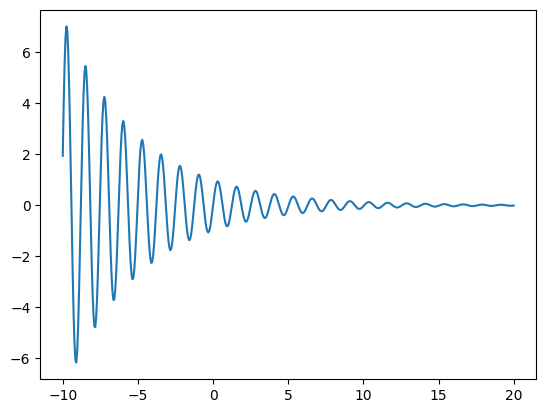

```python
import matplotlib.pyplot as plt

# Definiáljunk egy csillapított szinuszfüggvényt
def f(x):
    return np.sin(5*x) * np.exp(-0.2 * x)

# x és y értékek előállítása:
x = np.linspace(-10, 20, 500)
y = f(x)

# Ábrázolás matplotlib-pel
plt.plot(x, y)
plt.show()
```

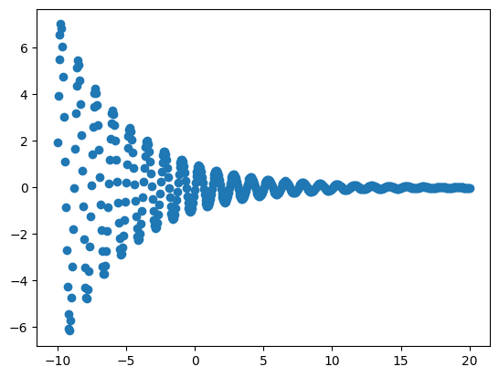

```python
# Alapból vonallal összekötött pontok, ezért fontos a sűrű felosztás
# Marker-szimbólumok: 'o' (kör), 's' (négyzet), '^' (háromszög), 'x', '.' (kis pont)
plt.plot(x, y, 'o') # kör
plt.show()
```

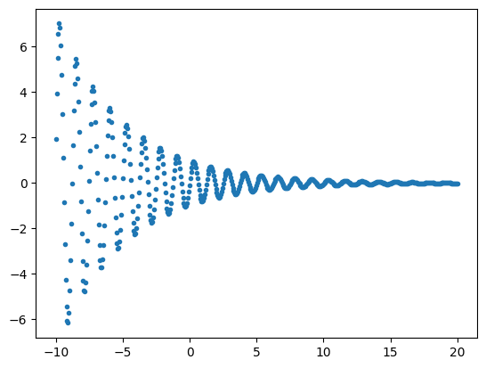

```python
plt.plot(x, y, '.') # kis pont
plt.show()
```

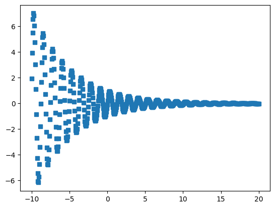

```python
plt.plot(x, y, 's') # négyzet
plt.show()
```

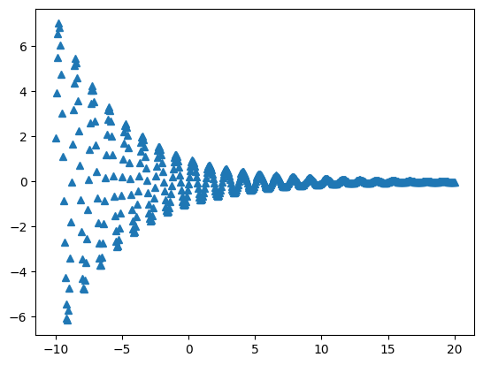

```python
plt.plot(x, y, '^') # háromszög
plt.show()
```

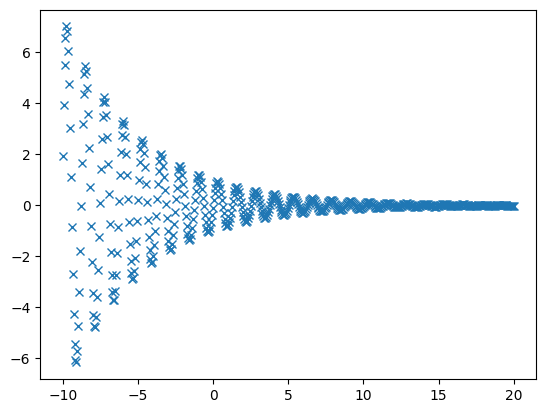

```python
plt.plot(x, y, 'x') # kereszt
plt.show()
```

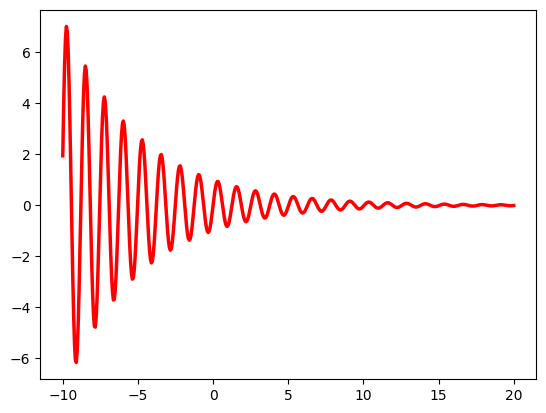

```python
# szín és vonalvastagság vagy marker méretének változtatása.
# Python-szintű színnevek: 'blue', 'green', 'red', 'cyan', 'magenta', 'yellow', 'black', 'white'
# Rövidítések: 'b', 'g', 'r', 'c', 'm', 'y', 'k', 'w'
plt.plot(x, y, color='r', linewidth=2.5)
plt.show()
```

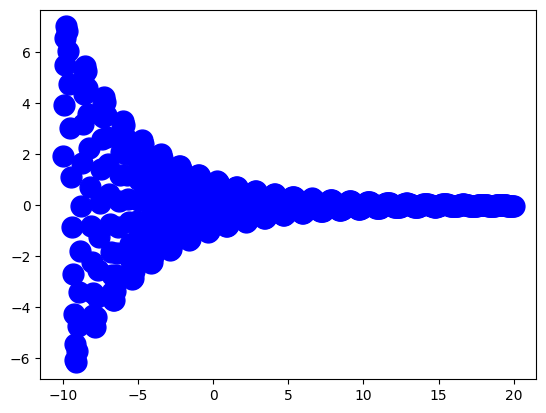

```python
plt.plot(x, y, 'o', markersize=15, color='b')
plt.show()
```

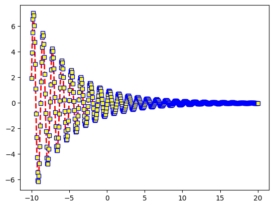

```python
# vonal és marker alkalmazása egyszerre
plt.plot(
    x, y,
    color='r',
    linestyle='--',      # szaggatott vonal
    linewidth=2,
    marker='s',          # négyzet
    markersize=6,
    markerfacecolor='yellow',
    markeredgecolor='b',
    markeredgewidth=1
)
plt.show()
```

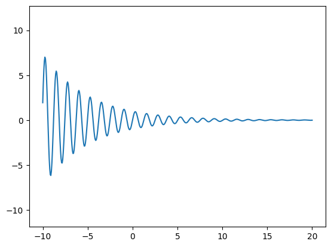

```python
# Az 'equal' biztosítja, hogy 1 egység x-en és y-n ugyanakkora hossz legyen.
plt.plot(x, y)
plt.axis('equal')
plt.show()
```

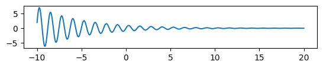

```python
# Egyedi aspect ratio
# Állítsuk be, hogy 1 egység x tengelyen háromszor annyi helyet kapjon, mint 1 egység y tengelyen
# aspect = (y_unit_length / x_unit_length)
fig, ax = plt.subplots()
ax.plot(x, y)
ax.set_aspect(1/3)
plt.show()
```

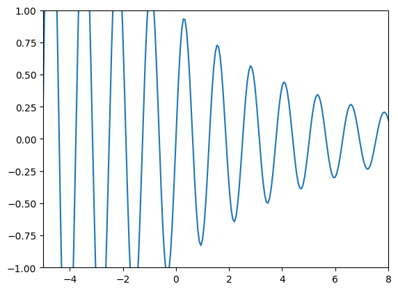

```python
# megjelenítési határ változtatása
plt.xlim(-5,8)
plt.ylim(-1,1)
plt.plot(x, y)
plt.show()
```